# Problem 7

2023-03-24

## Setup

```r
knitr::opts_chunk$set(echo = TRUE, warning = FALSE, message = FALSE)
library(DBI)
library(knitr)
db = dbConnect(RSQLite::SQLite(), dbname = "college_scorecard.sqlite")
```

```r
library(ggplot2)
library(knitr)
library(dplyr)
load('C:/Users/michb/Downloads/college_scorecard.Rda')

df$npt <- ifelse(!is.na(df$npt4_priv) == TRUE, df$npt4_priv, df$npt4_pub)
df <- df %>% select(-npt4_priv, -npt4_pub)
df <- df[!is.na(df$npt),]
df <- df[!is.na(df$omawdp8_ftft),]
df <- df[!is.na(df$md_earn_wne_p6),]
df$act_adjusted <- is.na(df$actcm25)
df$actcm25[df$act_adjusted == TRUE] <- min(df$actcm25, na.rm = TRUE)
df$actcm75[df$act_adjusted == TRUE] <- max(df$actcm75, na.rm = TRUE)
```

## Questions

### Value Violet

```r
violet_act <- 24
violet <- df %>% filter(violet_act >= actcm25 & violet_act <= actcm75)

violet <- violet %>%
  mutate(Composite = percent_rank((md_earn_wne_p6/npt))*.5 +
           percent_rank(omawdp8_ftft)*.5) %>%
  arrange(desc(Composite))

violet <- violet[1:100,]
violet$Composite_Category <- 'Top 100'
violet$Composite_Category[1:10] <- 'Top 10'
violet$Composite_Category[1:3] <- 'Top 3'
violet$Composite_Category <- factor(violet$Composite_Category, levels = c('Top 3','Top 10', 'Top 100'))

violet$alpha <- 1
violet$alpha[violet$Composite_Category == 'Top 100'] <- .2

t4 <- violet[1:5,c('instnm','stabbr','city','act_adjusted','actcm25','actcm75',
                   'md_earn_wne_p6', 'npt', 'omawdp8_ftft','Composite')]

kable(t4)
```

| instnm | stabbr | city | act_adjusted | actcm25 | actcm75 | md_earn_wne_p6 | npt | omawdp8_ftft | Composite |
| --- | --- | --- | --- | --- | --- | --- | --- | --- | --- |
| University of Health Sciences and Pharmacy in St. Louis | MO | Saint Louis | FALSE | 24 | 30 | 119219 | 26825 | 0.8300 | 0.9737719 |
| University of California-Los Angeles | CA | Los Angeles | TRUE | 10 | 36 | 55427 | 15023 | 0.9159 | 0.9733555 |
| University of California-Riverside | CA | Riverside | FALSE | 22 | 31 | 45632 | 11822 | 0.7609 | 0.9412989 |
| Massachusetts Maritime Academy | MA | Buzzards Bay | FALSE | 20 | 28 | 79354 | 21146 | 0.7592 | 0.9392173 |
| University of Utah | UT | Salt Lake City | FALSE | 22 | 29 | 47996 | 13572 | 0.7762 | 0.9379684 |

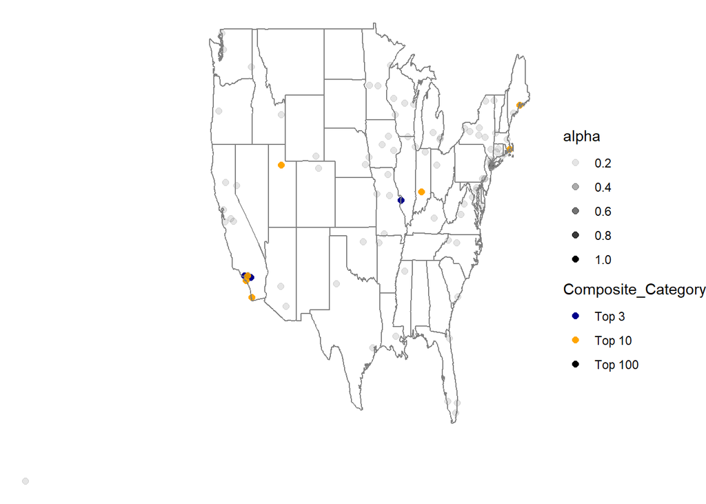

```r
p4 <- ggplot(violet, aes(longitude, latitude, color = Composite_Category, alpha = alpha)) +
  geom_point(size = 2) + borders("state") +
  scale_color_manual(values=c("darkblue","orange","black")) +
  theme_void()
p4
```

What are the top colleges for Violet? Any reason to advise against the top college?

The top colleges for violet are University of Health Sciences and Pharmacy in St. Louis, University of California-Los Angeles, University of California-Riverside, Massachusetts Maritime Academy, and University of Utah. For the top college it may be difficult for her to get in because she has a lower act score compared to others. Also, for University of California-Los Angeles, we don’t have the exact act 25th and 75th percentiles so it is hard to tell if her act score fits in between.

### Ocean Olivia

```r
coast_ocean <- c('AK','FL', 'CA', 'HI', 'LA','TX','NC','OR'
                 ,'ME','MA','SC','WA','NJ','NY','VA'
                 ,'GA','CT','AL','MS','RI','MD','DE',
                 'NH')

olivia_act <- 27
olivia <- df %>% filter(olivia_act >= actcm25 & olivia_act <= actcm75)
olivia$coastal_cities <- olivia$stabbr %in% coast_ocean

olivia <- olivia %>%
  mutate(Composite = (1-percent_rank(npt))*.75 +
           percent_rank(olivia$coastal_cities)*.25) %>%
  arrange(desc(Composite))

olivia <- olivia[1:100,]
olivia$Composite_Category <- 'Top 100'
olivia$Composite_Category[1:10] <- 'Top 10'
olivia$Composite_Category[1:3] <- 'Top 3'
olivia$Composite_Category <- factor(olivia$Composite_Category, levels = c('Top 3','Top 10', 'Top 100'))

olivia$alpha <- 1
olivia$alpha[olivia$Composite_Category == 'Top 100'] <- .2

t5 <- olivia[1:5,c('instnm','stabbr','city','act_adjusted','actcm25','actcm75',
                  'npt','coastal_cities','Composite')]

kable(t5)
```

| instnm | stabbr | city | act_adjusted | actcm25 | actcm75 | npt | coastal_cities | Composite |
| --- | --- | --- | --- | --- | --- | --- | --- | --- |
| CUNY Hunter College | NY | New York | FALSE | 25 | 31 | 2158 | TRUE | 0.8609937 |
| CUNY Bernard M Baruch College | NY | New York | FALSE | 26 | 30 | 2264 | TRUE | 0.8602008 |
| Be’er Yaakov Talmudic Seminary | NY | Spring Valley | TRUE | 10 | 36 | 2590 | TRUE | 0.8594080 |
| CUNY Lehman College | NY | Bronx | TRUE | 10 | 36 | 2614 | TRUE | 0.8586152 |
| Talmudical Seminary of Bobov | NY | Brooklyn | TRUE | 10 | 36 | 2775 | TRUE | 0.8578224 |

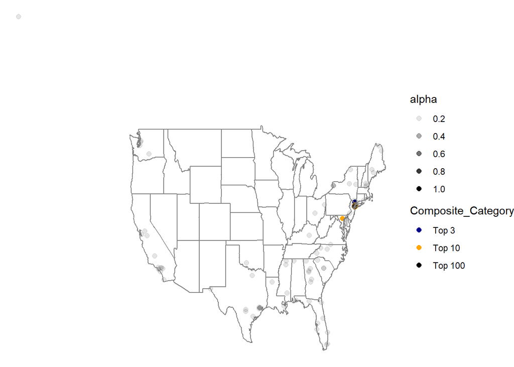

```r
p5 <- ggplot(olivia, aes(longitude, latitude, color = Composite_Category, alpha = alpha)) +
  geom_point(size = 2) + borders("state") +
  scale_color_manual(values=c("darkblue","orange","black")) +
  theme_void()
p5
```

What are the top colleges for Olivia? Any reason to advise against the top college?

The top colleges for Olivia are CUNY Hunter College, CUNY Bernard M Baruch College, Be’er Yaakov Talmudic Seminary, CUNY Lehman College, and Talmudical Seminary of Bobov. The top college seems to fit what she is looking for quite well. All of these colleges are priced reasonably well. Although, the last three colleges within the top 5 had to have their act score percentiles adjusted, so it is difficult to say about those.

### Local Larry

```r
larry_act <- 23
larry <- df %>% filter(larry_act >= actcm25 & larry_act <= actcm75)

# load city data from maps package
library(maps)
larry_city <- 'Columbia MO'
df_city <- us.cities[us.cities$name == larry_city,]


library(geosphere)
# meter to miles
distance_to_larry_home <- function(x,y){
  distm(c(x, y), c(df_city$long, df_city$lat), fun = distHaversine) * 0.000621371
}

larry$distance_home <- mapply(distance_to_larry_home, larry$longitude, larry$latitude)
larry <- larry %>%
  mutate(Composite = (1-percent_rank(distance_home))*.5 +
           percent_rank(omawdp8_ftft)*.3 +
           percent_rank(ugds)*.2) %>%
  arrange(desc(Composite))

larry <- larry[1:100,]
larry$Composite_Category <- 'Top 100'
larry$Composite_Category[1:10] <- 'Top 10'
larry$Composite_Category[1:3] <- 'Top 3'
larry$Composite_Category <- factor(larry$Composite_Category, levels = c('Top 3','Top 10', 'Top 100'))

larry$alpha <- 1
larry$alpha[larry$Composite_Category == 'Top 100'] <- .2

t3 <- larry[1:5,c('instnm','stabbr','city','act_adjusted','actcm25','actcm75',
                  'distance_home','omawdp8_ftft','ugds','Composite')]

kable(t3)
```

| instnm | stabbr | city | act_adjusted | actcm25 | actcm75 | distance_home | omawdp8_ftft | ugds | Composite |
| --- | --- | --- | --- | --- | --- | --- | --- | --- | --- |
| University of Missouri-Columbia | MO | Columbia | FALSE | 23 | 29 | 0.3303275 | 0.6982 | 22622 | 0.9490995 |
| Iowa State University | IA | Ames | FALSE | 21 | 28 | 223.7953033 | 0.7589 | 26566 | 0.9419734 |
| University of Iowa | IA | Iowa City | FALSE | 22 | 29 | 192.1977056 | 0.7297 | 21909 | 0.9346124 |
| Illinois State University | IL | Normal | FALSE | 21 | 26 | 207.8306604 | 0.6998 | 17955 | 0.9146437 |
| Bradley University | IL | Peoria | FALSE | 22 | 28 | 188.0695959 | 0.7859 | 4570 | 0.9115897 |

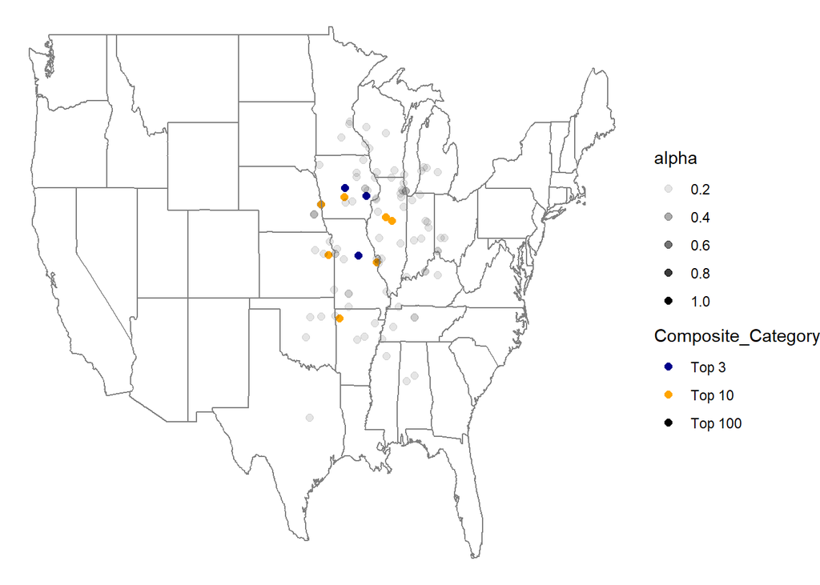

```r
p3 <- ggplot(larry, aes(longitude, latitude, color = Composite_Category, alpha = alpha)) +
  geom_point(size = 2) + borders("state") +
  scale_color_manual(values=c("darkblue","orange","black")) +
  theme_void()
p3
```

What are the top colleges for Larry? Any reason to advise against the top college?

The top colleges for Larry are University of Missouri-Columbia, Iowa State University, University of Iowa, Illinois State University, and Bradley University. Larry’s top college seems like a good college since it is so close to him and has a reasonable graduation rate and cost. The rest of the top 5 colleges are much further than his top college, yet they are still great options.